# inlinehelp_view_study_parts_routing_en-us – IRTlib

### Summary of Routing within Survey Parts

The sequence of *CBA ItemBuilder* tasks can be defined here using *Blockly* (i.e. a form of visual programming). *Blockly*-based sequencing is available if the option *Enable Routing* is selected for a *Survey Part*. The option can be found in the *Info* section of a *Survey Part*. If it is activated, the *Survey Part* contains the entry *Routing*.

Overview:

- Examples: linear sequence, simple test booklets, sequence with time restriction and booklet designs
- Quick guide: General notes on the *Blockly* editor
- Basics: Using the *Blockly* editor
  - Displaying items or item lists
  - Definition of time limits
  - Changes to the test administrator menu
- Deepening: Advanced *Blockly* use
  - Flow control with conditions
  - Flow control with loops
  - Operators for numbers, text, times and lists.
  - More in-depth information on *Blockly*-variables and *Blockly*-functions
  - Use of item results in the flow definition
  - *Blockly* operators for encoding missing values and for writing data
- commenting on *Blockly* code
- Customisation of the presentation of *Blockly* code

#### Examples

The basic idea of using *Blockly* for the definition of processes in *computer-based assessments* will first be illustrated with a few examples.

- **Example for linear sequence**

> Based on the *CBA ItemBuilder Tasks* added to a survey part in the *Items* view, a linear sequence of *Tasks* corresponds to the following *Blockly* definition:

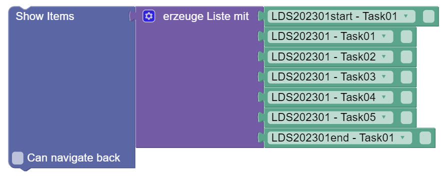

> A list of *CBA ItemBuilder Tasks* is passed to the *Blockly* element *Show Items*, which is created with the operator *create list with*. The list is processed in the order shown, whereby each *CBA ItemBuilder Tasks* is displayed until the `NEXT_TASK`- *Command* is executed.

> An equivalent formulation of a linear sequence can also be made with several *Show Items* blocks if no back navigation is necessary:

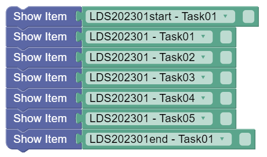

- **Example for simple test booklets**

> With the help of an variable (here: *booklet*) and a simple *if/make*-condition, it is now possible to define a sequence that administers different items depending on the value of the variable:

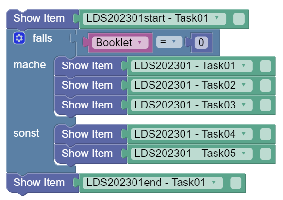

> The items for start and end are always administered, tasks 1-3 only if the variable *Booklet* has the value *0*, tasks 4 and 5 if the variable *Booklet* has a value other than *0*.

> Alternatively, the identical sequence can also be created using the *Blockly* operator for displaying item lists:

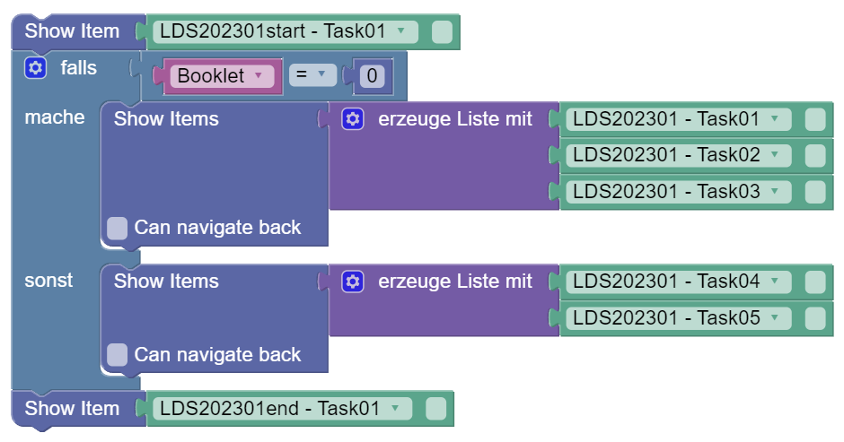

> Both variants are completely equivalent in terms of functionality, but the second approach with lists allows the use of the back navigation option within the booklet-specific tasks.

**Example for process with time limit**

> To implement time-limited sections within a survey section using the *Blockly* configuration, the following *Blockly* component can be used:

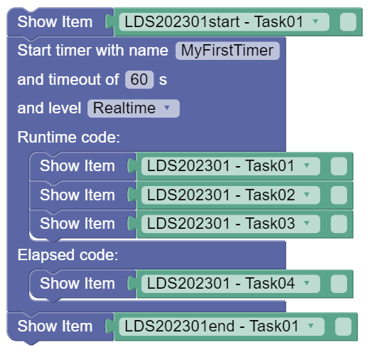

> Each sequence begins with a start task that is not time-limited and ends with an end task that is also not time-limited. In between, there is a time limit for a section called *MyFirstTimer*, which has a time limit of *60* seconds.

> Tasks 1, 2 and 3 are displayed in the *Runtime code* section with a time limit. If a timeout occurs, i.e. the three tasks are not processed within the *60* seconds, task 4 is displayed (also without a time limit).

**Example of simple booklet design with time limit**

> For many items, the definition of *booklet designs*, i.e. task sequences with balanced positions, can be simplified using functions or lists.

> If no back navigation is necessary, functions can be used for the definition of clusters:

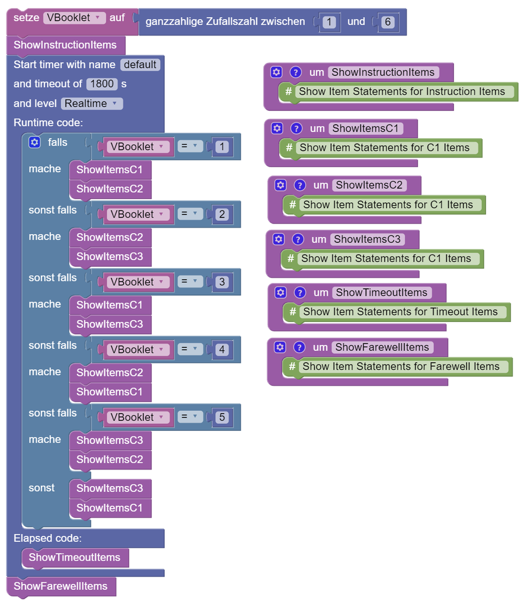

> With back navigation, the functions can return lists of tasks:

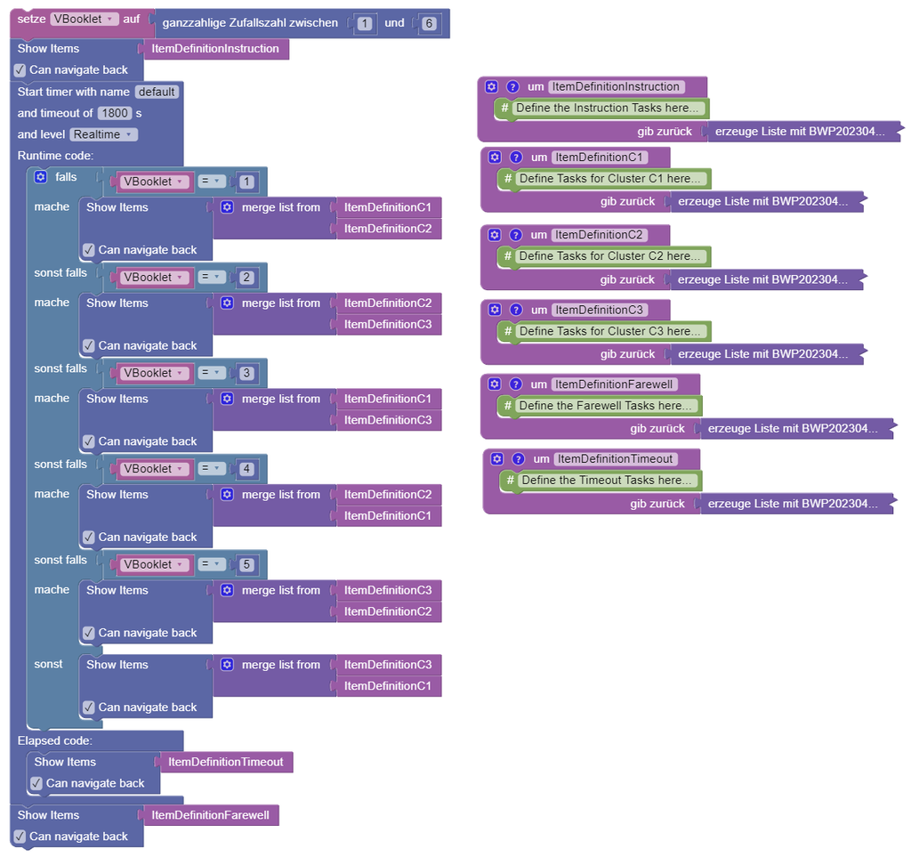

> For more information see [here](https://cba.itembuilder.de/chapter-cba-principles.html#introduction-to-rotations).

(top)

#### Notes on using the *Blockly* editor

Processes are defined in the visual *Blockly* editor. Execution begins with the element that is aligned furthest up. If necessary, the workspace can be automatically aligned using the tidy-up function. To add *Blockly* operators, they can be dragged and dropped from the palette.

- **Delete**: Operators can be dragged to the recycle bin to delete them. Selected *Blockly* elements can also be deleted using the *Delete(delete)* button. Alternatively, selected *Blockly* elements can also be deleted via the context menu.
- **Redo/Undo**: Individual actions can be undone within the *Blockly* editor. The key combination ‘Ctrl + Z’ can be used for this. Pressing ‘Ctrl + Y’ repeats an action. By clicking in an empty section of the *Blockly* editor, you can access a context menu, which also contains the options for *Undo* and *Redo*:

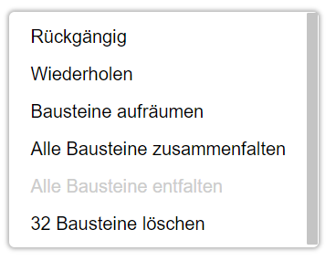

- **Save**: Customisations in the *Blockly* editor must be saved. The floppy disc symbol is available for this purpose at the bottom right:

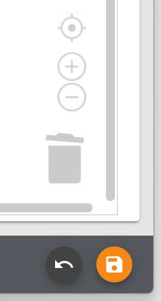

> If you want to discard the change (as a whole), you can use the discard icon at the bottom right.
- **Zoom**: The view in the workspace can be enlarged with the icons `+` and reduced with `-`.
- **Context menu**: Further options are available via the right mouse button (context menu) in the *Blocky* editor. To call up these functions, a secondary click (right mouse button) must be performed on a *Blockly* element:
  - Copy duplicates the selected *Blockly* element, including all connected elements.
  - Commenting on blocks is possible.
  - Blocks can be deactivated/activated.
  - Some block types allow you to change the display form external/internal.
  - Blocks that contain further blocks can be folded/unfolded.
  - Blocks can also be deleted via the context menu.

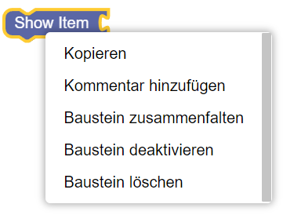

> Some *Blockly* elements also provide a *Help* entry in the context menu, which refers to generally accessible *Blockly* documents (https://github.com/google/blockly/wiki/).

(top)

### Use of *Blockly* for flow control

The basic functions for using the *Blockly* environment to control assessments can be found in the *Session* section.

#### Show individual items

*CBA ItemBuilder* tasks that have been imported in the *Items* view for a survey section can be accessed in the flow control, as shown in the examples above, using the following *Blockly* element for *Tasks*:

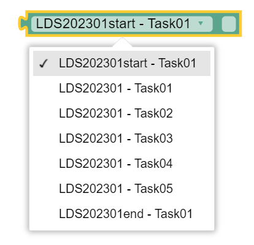

The element, which can be found in the *Session* section of the *Blockly* editor palette, can be configured using the selection list. Each *Blockly* element for tasks can refer to exactly one specific task, i.e. a flow definition usually consists of several such elements.

*Blockly* elements for tasks cannot be inserted directly into the flow, but are used together with a *Show Item* element:

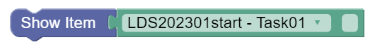

The example for simple test booklets illustrates that sequences in the *blockly* definition are often defined by a sequence of several *show item* operators. *Show Item* operators can be inserted into conditions and loops, both within the main flow and within functions.

#### Use of scopes (scopes)

With the help of *Blocky*-based flow control, it is also possible to administer *CBA ItemBuilder* tasks multiple times within a flow:

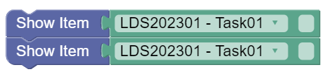

When an item is called up again, the status from the last visit is restored, i.e. processing is continued. If items are to be resubmitted several times, i.e. unedited, automatic restoration may not be desired. The checkbox for specifying a *scope* (scope) can be optionally activated for this purpose:

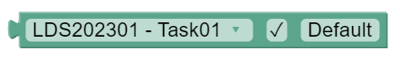

If nothing else is specified, the item is administered in the “default” scope. Alternatively, a text can be defined, as shown in the following example:

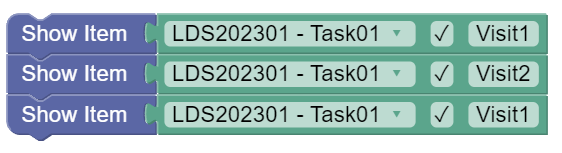

On the first visit, the task is displayed in the *Scope* “Visit1”. This is followed by a new, independent display of the task in a different *scope* (“Visit2”). In the third call, the task is displayed again with the data that was already collected during the first visit (i.e. the *Scope* “Visit1” is used again).

#### Display multiple items (item lists)

As shown in the example for linear sequence, linear tests can also be displayed using lists of tasks.

Lists can be used with the *Blockly* operator *Show Items*:

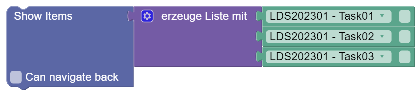

- **Back navigation**: The *Show Items* element for lists can be configured via the *Can navigate back* property. If this property is selected, *CBA ItemBuilder*-*Tasks* can use the *Command* `BACK_TASK` to request navigation to the previous *CBA ItemBuilder Tasks*.
- **Cancelling lists**: The use of lists also allows lists to be cancelled. Lists can be cancelled in two ways:
  - The *Command* `CANCEL_TASK`, which can be used within CBA ItemBuilder Tasks, is called.
  - In the test administrator menu, which has been configured for the study and, if necessary, customised using the *Blockly* operator Edit test administrator menu, the function *Cancel item list* is called.

> This cancels the administration of an item list and the *Blockly* process is continued after the *Show Items* block.

#### Display of items with storage of the results

The operators *Show Item* (for individual items) and *Show Items* (for item lists) are also available as operators for value assignments:

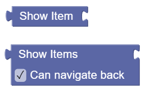

These can be used to assign item processing results to variables (string or array) and then evaluate them for process control.

- Single task:

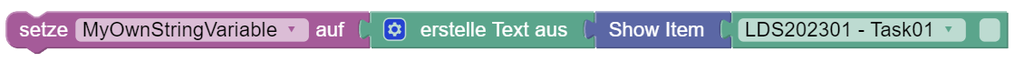

- List of tasks:

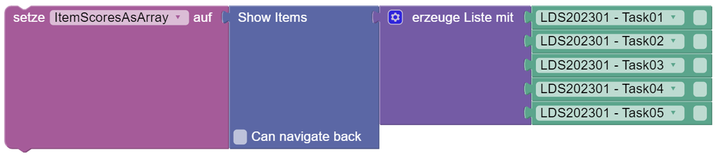

#### Definition of time limits

As already illustrated in the example process with time restriction, the *Blockly* block *Start time with name* can be used to implement the time-restricted administration of items.

The *Blockly* element *Start timer with name* allows the definition of time limits. Each time limit can have its own name. The time must also be specified in seconds. This can be used to define the type of time to be used:

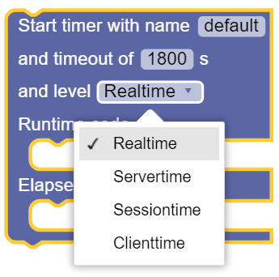

- Realtime: The timer runs in real time. It is not affected by server downtimes or a session restart.
- Servertime: The timer runs in server time. Is not affected by a session restart, but does not take server downtime into account.
- Sessiontime: The timer runs within a session. Is interrupted in the event of an interruption due to server downtime or a session restart.
- Clienttime: The timer only runs in client time and is also interrupted when the session is paused.

Finally, two positions can be filled with further *blockly* operators (such as one or more *Show Item* blocks for displaying individual items or one or more *Show Items* blocks for displaying lists):

- Runtime code: These blocks are filled until the defined time has elapsed.
- Elapsed code: These blocks are only filled in if the *Runtime code* was not completed within the time.

#### *Blockly* operators for the test administrator menu

In the study definition, test administrator menu functions can be created for one or more roles. Roles combine different functions that can be differentiated using the password to be entered by the test administrator.

**Customise standard functions**: The following standard functions can be defined for a study in the *Info* / *Test leader menu* section:

- *Navigation*: Task forward / Task back
- Lists*: Cancel item list
- Exit*: End survey part and end session
- Volume control*: Adjust the audio volume during the assessment

> During the processing of a survey section, the following *blockly* operator can be used to customise the test administrator menu in the flow control for specific contexts:

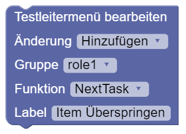

> The test administrator menu can be changed for each of the standard functions (in the *Function* section) for a role (in the *Group* section) as well as the button label (in the *Label* section):
- *Add*: Function is added to the test leader menu
- *Remove*: Function is removed from the test conductor menu
- Deactivate*: Function is deactivated in the test conductor menu
- Activate*: Function is activated in the test conductor menu

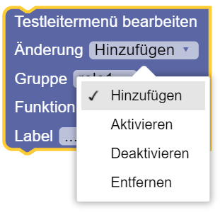

> Calling this *Blockly* operator in the test sequence defines the behaviour of the test administrator menu in the rest of the test sequence. In contrast to *Remove*, *deactivated* functions remain visible in the Test Manager menu, but cannot be executed (until they are *activated* again).

**Using *Blockly* functions in the Test Manager menu**: The *Blockly* operator for editing the test leader menu also contains the option to execute *Blockly* code (*ExecuteBockly*) in the *Function* section:

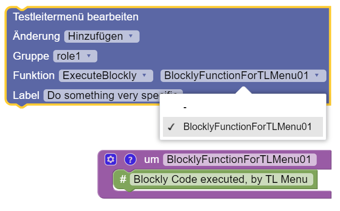

> If *ExecuteBlockly* is selected, a function defined within the *Blockly* editor can be selected in the *Blockly* element *Edit test administrator menu*. The *Blockly* operators defined in this function are then executed when a test leader selects the corresponding button in the test leader menu at runtime.

(top)

### Advanced *Blockly* usage

#### Flow control with conditions

The *Logic* section contains the *Blockly* operator *if/make*, which can be used to implement conditions in the flow. Conditions are logical expressions, e.g. checking whether a preload variable has a certain value:

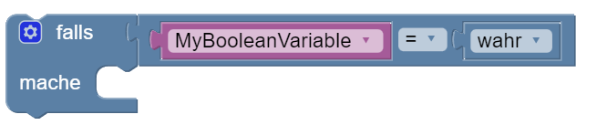

The blocky operators defined within the condition block (i.e. next to *make*) are only executed if the condition (*if*) is fulfilled. The example checks whether a Boolean variable has the value `true`.

The condition is defined as a separate block that is connected to the *blockly* operator *if/make*. Here are the two components separately:

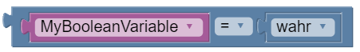